# Praca Domowa 3

Adam Rydelek

01 - 04 - 2019

# 1 Wprowadzenie

Tematem pracy jest przeprowadzenie Feature Engineering na zbiorze danych z **Walmart**. Na początek krótkie przedstawienie zbioru:

```r
summary(train)
```

```
##     TripType       VisitNumber          Weekday            Upc
##  Min.   :  3.00   Min.   :     5   Friday   : 96247   Min.   :8.340e+02
##  1st Qu.: 27.00   1st Qu.: 49268   Monday   : 83130   1st Qu.:3.400e+09
##  Median : 39.00   Median : 97074   Saturday :122096   Median :7.050e+09
##  Mean   : 58.58   Mean   : 96168   Sunday   :133975   Mean   :3.061e+10
##  3rd Qu.: 40.00   3rd Qu.:144316   Thursday : 67962   3rd Qu.:3.007e+10
##  Max.   :999.00   Max.   :191347   Tuesday  : 72529   Max.   :9.790e+11
##                                    Wednesday: 71115   NA's   :4129
##    ScanCount               DepartmentDescription FinelineNumber
##  Min.   :-12.000   GROCERY DRY GOODS  : 70402    Min.   :   0
##  1st Qu.:  1.000   DSD GROCERY        : 68332    1st Qu.:1404
##  Median :  1.000   PRODUCE            : 51115    Median :3352
##  Mean   :  1.109   DAIRY              : 43820    Mean   :3727
##  3rd Qu.:  1.000   PERSONAL CARE      : 41969    3rd Qu.:5501
##  Max.   : 71.000   IMPULSE MERCHANDISE: 28712    Max.   :9998
##                    (Other)            :342704    NA's   :4129
```

```r
DT::datatable(head(train,100))
```

|  | TripType | VisitNumber | Weekday | Upc | ScanCount | DepartmentDescription | FinelineNumber |
| --- | --- | --- | --- | --- | --- | --- | --- |
| 1 | 999 | 5 | Friday | 68113152929 | -1 | FINANCIAL SERVICES | 1000 |
| 2 | 30 | 7 | Friday | 60538815980 | 1 | SHOES | 8931 |
| 3 | 30 | 7 | Friday | 7410811099 | 1 | PERSONAL CARE | 4504 |
| 4 | 26 | 8 | Friday | 2238403510 | 2 | PAINT AND ACCESSORIES | 3565 |
| 5 | 26 | 8 | Friday | 2006613744 | 2 | PAINT AND ACCESSORIES | 1017 |
| 6 | 26 | 8 | Friday | 2006618783 | 2 | PAINT AND ACCESSORIES | 1017 |
| 7 | 26 | 8 | Friday | 2006613743 | 1 | PAINT AND ACCESSORIES | 1017 |
| 8 | 26 | 8 | Friday | 7004802737 | 1 | PAINT AND ACCESSORIES | 2802 |
| 9 | 26 | 8 | Friday | 2238495318 | 1 | PAINT AND ACCESSORIES | 4501 |
| 10 | 26 | 8 | Friday | 2238400200 | -1 | PAINT AND ACCESSORIES | 3565 |

[output cut: 90 more lines]

Naszym Target’em jest zmienna *TripType*. Zobaczmy, jak poradzi sobie model **gbm** na danych bez żadnych modyfikacji.

| mmce | acc |
| --- | --- |
| 0.6571784 | 0.3428216 |

| LogErr |
| --- |
| 2.43225 |

Jak można zauważyć model nie radzi sobie dobrze na tych danych, spróbuję to poprawić za pomocą zamiany zmiennych na inne, które będą lepiej współpracowały z modelem predykcyjnym.

# 2 Feature Engineering

Jako, że podczas jednej wycieczki do sklepu ludzie kupują wiele przedmiotów to dla danego *Visit Number* było kilka różnych wartości DepartmentDescription, Upc, czy FinelineNumber. Uznałem, że najbardziej logiczne będzie sprowadzenie ich do najczęstszej kategorii występującej podczas jednych zakupów. W tem sposób powstały zmienne *MostFrequentDepartment*, *MostFrequentFineline*, *MostFrequentUPC*. Aby ujednolicić jeszcze bardziej osobne wizyty dodałem kolumnę *ProductCount*, która sumowała liczbę produktów zakupionych na raz. Na koniec zliczyłem ilość przedmiotów kupionych ogółem i tych zwróconych, na podstawie czego powstała kolumna *BoughtByReturned*, która oznacza (ilość kupionych przedmiotów bez zwrotów)/ilość kupionych przedmiotów ogółem. Sprójrzmy na podsumowanie ramki danych po tych modyfikacjach.

```r
summary(train4)
```

```
##     TripType      VisitNumber          Weekday       ProductCount
##  Min.   :  3.0   Min.   :     5   Friday   :14993   Min.   :  1.000
##  1st Qu.:  8.0   1st Qu.: 48085   Monday   :11839   1st Qu.:  2.000
##  Median : 26.0   Median : 95993   Saturday :16690   Median :  4.000
##  Mean   :108.2   Mean   : 95742   Sunday   :16965   Mean   :  6.822
##  3rd Qu.: 39.0   3rd Qu.:143537   Thursday :11043   3rd Qu.:  8.000
##  Max.   :999.0   Max.   :191347   Tuesday  :11325   Max.   :209.000
##                                   Wednesday:11392
##         MostFrequentDepartment MostFrequentFineline MostFrequentUPC
##  DSD GROCERY       :11058      Min.   :   7         Min.   :3.107e+03
##  GROCERY DRY GOODS : 7358      1st Qu.:1000         1st Qu.:2.238e+09
##  PERSONAL CARE     : 5690      Median :3504         Median :7.411e+09
##  DAIRY             : 5499      Mean   :3603         Mean   :3.248e+10
##  FINANCIAL SERVICES: 5111      3rd Qu.:4504         3rd Qu.:6.811e+10
##  PRODUCE           : 4841      Max.   :9538         Max.   :8.806e+11
##  (Other)           :54690
##  BoughtByReturned
##  Min.   :0.0000
##  1st Qu.:1.0000
##  Median :1.0000
##  Mean   :0.9384
##  3rd Qu.:1.0000
##  Max.   :1.0000
##
```

```r
DT::datatable(head(train4,100))
```

|  | TripType | VisitNumber | Weekday | ProductCount | MostFrequentDepartment | MostFrequentFineline | MostFrequentUPC | BoughtByReturned |
| --- | --- | --- | --- | --- | --- | --- | --- | --- |
| 1 | 999 | 5 | Friday | 1 | FINANCIAL SERVICES | 1000 | 68113152929 | 0 |
| 2 | 30 | 7 | Friday | 2 | PERSONAL CARE | 8931 | 60538815980 | 1 |
| 4 | 26 | 8 | Friday | 22 | PAINT AND ACCESSORIES | 3565 | 2310010776 | 0.909090909090909 |
| 26 | 8 | 9 | Friday | 3 | PRODUCE | 4504 | 7410811099 | 1 |
| 29 | 8 | 10 | Friday | 3 | DSD GROCERY | 4504 | 7410811099 | 1 |
| 32 | 35 | 11 | Friday | 4 | IMPULSE MERCHANDISE | 3565 | 2238403510 | 1 |
| 36 | 41 | 12 | Friday | 7 | BOYS WEAR | 1017 | 2006613743 | 1 |
| 43 | 21 | 15 | Friday | 8 | FABRICS AND CRAFTS | 1017 | 7004802737 | 1 |
| 51 | 6 | 17 | Friday | 4 | CANDY, TOBACCO, COOKIES | 3565 | 2238403510 | 1 |
| 55 | 42 | 19 | Friday | 9 | MENS WEAR | 2802 | 7004802737 | 1 |

[output cut: 90 more lines]

Teraz sprawdzę, czy te działania przyniosły poprawę działania modelu.

[output not shown]

| LogErr |
| --- |
| 1.23324 |

# 3 Porównanie

## 3.1 Model bez modyfikacji danych

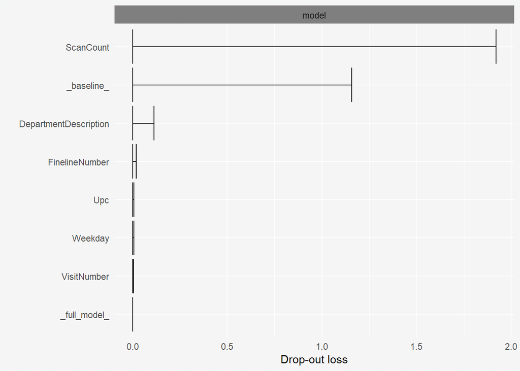

## 3.2 Model z Feature Engineering

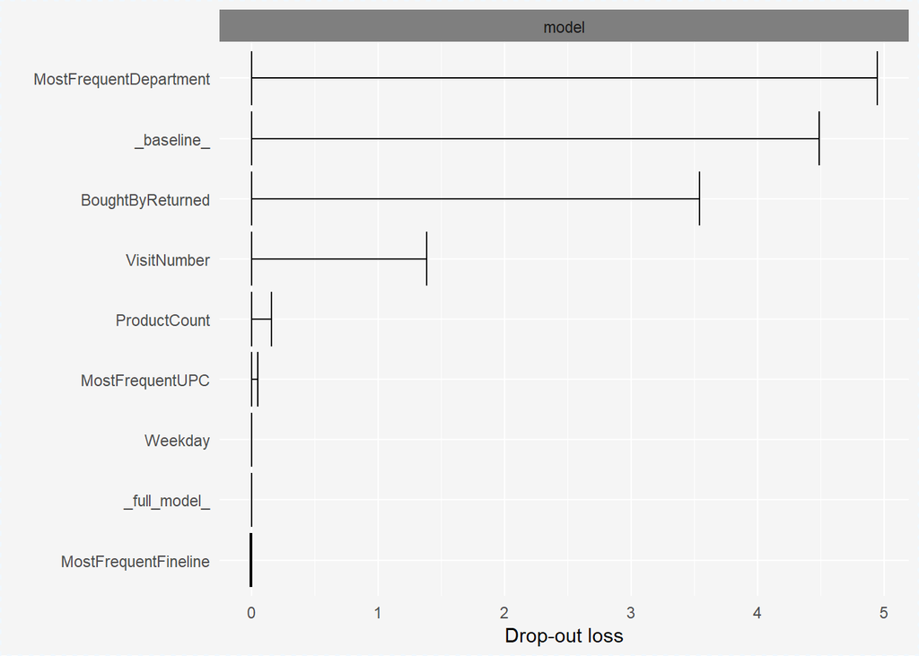